# Predicting Powerlifting Performance

### A data science case study · Carlos Abel Vivanco / AbleVLabs

This project takes real competition data and runs the complete machine-learning pipeline: load, explore, clean, visualize, engineer features, model, evaluate, and interpret. The objective is to **predict a lifter's competition total** from bodyweight, age, sex, and equipment, and to identify **what actually drives strength**.

The data is **real IPF competition results from OpenPowerlifting** (public domain), obtained via the [TidyTuesday](https://github.com/rfordatascience/tidytuesday) project. This notebook works with a 1,000-lift sample; the full IPF subset holds 41,152 records.

## The tools

The analysis uses the standard Python data-science stack: **pandas** for tabular data, **NumPy** for numerical work, **Matplotlib** and **Seaborn** for visualization, and **scikit-learn** for modeling.

```python
import pandas as pd
import numpy as np
import matplotlib.pyplot as plt
import seaborn as sns

sns.set_theme(style="whitegrid")
plt.rcParams["figure.figsize"] = (8, 4.5)
pd.set_option("display.max_columns", None)
```

## 1. Loading the data and a first look

Any analysis begins by inspecting the data before changing it. The CSV is loaded into a DataFrame, and four standard questions are asked of it: how large it is (`.shape`), what the rows look like (`.head()`), the type of each column and where values are missing (`.info()`), and the rough scale of the numbers (`.describe()`).

```python
df = pd.read_csv("powerlifting.csv")
print("shape (rows, columns):", df.shape)
df.head()
```

```
shape (rows, columns): (1000, 8)
```

|  | Sex | Age | BodyweightKg | Best3SquatKg | Best3BenchKg | Best3DeadliftKg | TotalKg | Equipment |
| --- | --- | --- | --- | --- | --- | --- | --- | --- |
| 0 | M | 30.0 | 59.60 | 200.0 | 142.5 | 207.5 | 550.0 | Wraps |
| 1 | M | 15.5 | 134.00 | 130.0 | 60.0 | 170.0 | 360.0 | Raw |
| 2 | F | 21.5 | 48.00 | NaN | 72.5 | NaN | NaN | Single-ply |
| 3 | M | 40.5 | 59.40 | 177.5 | 130.0 | 185.0 | 492.5 | Single-ply |
| 4 | M | 72.5 | 92.22 | NaN | 150.0 | NaN | NaN | Single-ply |

```python
df.info()
```

```
<class 'pandas.core.frame.DataFrame'>
RangeIndex: 1000 entries, 0 to 999
Data columns (total 8 columns):
 #   Column           Non-Null Count  Dtype
---  ------           --------------  -----
 0   Sex              1000 non-null   object
 1   Age              942 non-null    float64
 2   BodyweightKg     998 non-null    float64
 3   Best3SquatKg     660 non-null    float64
 4   Best3BenchKg     945 non-null    float64
 5   Best3DeadliftKg  650 non-null    float64
 6   TotalKg          633 non-null    float64
 7   Equipment        1000 non-null   object
dtypes: float64(6), object(2)
memory usage: 62.6+ KB
```

```python
df.describe()
```

|  | Age | BodyweightKg | Best3SquatKg | Best3BenchKg | Best3DeadliftKg | TotalKg |
| --- | --- | --- | --- | --- | --- | --- |
| count | 942.000000 | 998.000000 | 660.000000 | 945.000000 | 650.000000 | 633.000000 |
| mean | 34.982484 | 81.477896 | 218.085606 | 143.486243 | 223.163846 | 577.784360 |
| std | 14.900947 | 25.648374 | 72.056128 | 59.555929 | 61.703211 | 179.821815 |
| min | 14.000000 | 41.900000 | 55.000000 | 25.000000 | 87.500000 | 177.500000 |
| 25% | 22.500000 | 61.745000 | 160.000000 | 97.500000 | 172.500000 | 430.000000 |
| 50% | 31.500000 | 75.000000 | 220.000000 | 137.500000 | 225.000000 | 582.500000 |
| 75% | 45.500000 | 97.275000 | 265.000000 | 182.500000 | 270.000000 | 705.000000 |
| max | 85.500000 | 214.000000 | 445.000000 | 400.000000 | 375.000000 | 1125.000000 |

The output reveals issues typical of real-world data. `Age` and several of the lift columns have fewer non-null entries than the row count, indicating **missing values** (many entries are single-lift performances with no full total). `BodyweightKg` can carry the odd extreme value, and `Sex` and `Equipment` are text **categories** rather than numbers. Each is handled below.

```python
for col in ["Sex", "Equipment"]:
    print(col, "->", df[col].unique())
```

```
Sex -> ['M' 'F']
Equipment -> ['Wraps' 'Raw' 'Single-ply']
```

## 2. Cleaning the data

Each cleaning decision is deliberate and documented, since every row dropped or altered is a modeling choice.

### Standardizing the category

`Sex` is forced to uppercase so that any inconsistent casing collapses into a single category.

```python
df["Sex"] = df["Sex"].str.upper()
print(df["Sex"].value_counts())
```

```
Sex
M    687
F    313
Name: count, dtype: int64
```

### Removing impossible values

A human competitor does not weigh 9 kg or 1900 kg, so only physically plausible bodyweights are kept.

```python
before = len(df)
df = df[(df["BodyweightKg"] >= 35) & (df["BodyweightKg"] <= 230)]
print(f"removed {before - len(df)} implausible-bodyweight rows")
```

```
removed 2 implausible-bodyweight rows
```

### Handling missing values

Two situations are treated differently. Because `TotalKg` is the prediction target, rows missing it are **dropped**: a model cannot learn from a missing answer. `Age` is a feature, so rather than discard those rows it is **imputed** with the median, preserving the remaining information in each row. The median is preferred over the mean because it is robust to outliers.

```python
df = df.dropna(subset=["TotalKg"])
median_age = df["Age"].median()
df["Age"] = df["Age"].fillna(median_age)
print("median age used for imputation:", median_age)
print("rows remaining for analysis:", len(df))
```

```
median age used for imputation: 28.0
rows remaining for analysis: 632
```

## 3. Exploratory data analysis

The clean data is explored visually to understand each variable and the relationships between them.

### Distribution of the target

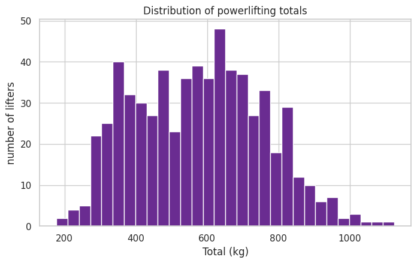

```python
plt.hist(df["TotalKg"], bins=30, color="#6a2c91", edgecolor="white")
plt.xlabel("Total (kg)"); plt.ylabel("number of lifters")
plt.title("Distribution of powerlifting totals"); plt.show()
```

### Bodyweight versus total

Each point is a lifter. The upward slope confirms that heavier lifters tend to total more.

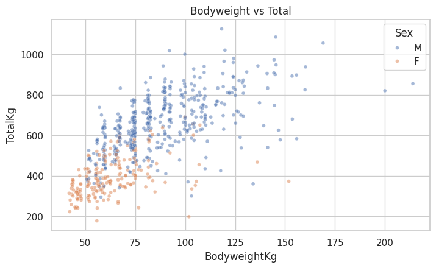

```python
sns.scatterplot(data=df.sample(min(len(df), 3000), random_state=1),
                x="BodyweightKg", y="TotalKg", hue="Sex", alpha=0.5, s=18)
plt.title("Bodyweight vs Total"); plt.show()
```

### Total by sex and by equipment

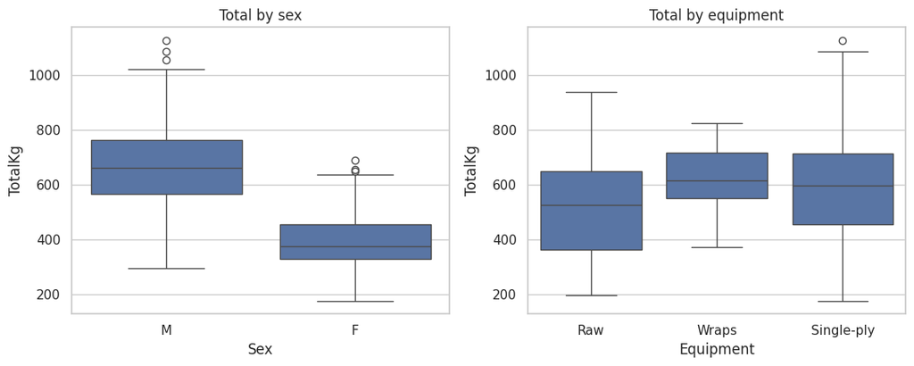

```python
fig, ax = plt.subplots(1, 2, figsize=(11, 4.5))
sns.boxplot(data=df, x="Sex", y="TotalKg", ax=ax[0]); ax[0].set_title("Total by sex")
sns.boxplot(data=df, x="Equipment", y="TotalKg",
            order=["Raw","Wraps","Single-ply"], ax=ax[1]); ax[1].set_title("Total by equipment")
plt.tight_layout(); plt.show()
```

### Strength across age

Average total per five-year age band.

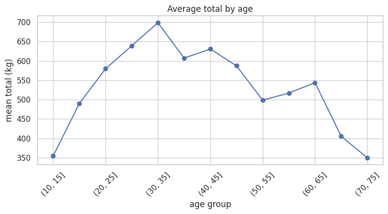

```python
age_bins = pd.cut(df["Age"], bins=range(10, 85, 5))
df.groupby(age_bins, observed=True)["TotalKg"].mean().plot(marker="o")
plt.ylabel("mean total (kg)"); plt.xlabel("age group")
plt.title("Average total by age"); plt.xticks(rotation=45)
plt.tight_layout(); plt.show()
```

### Correlation heatmap

Correlation, from -1 to 1, measures how strongly two numeric columns move together.

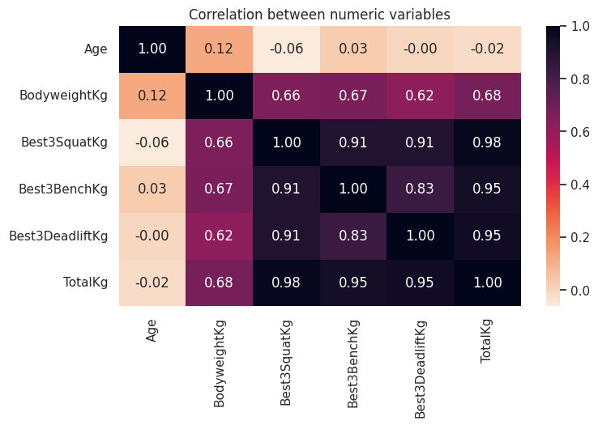

```python
num = df[["Age","BodyweightKg","Best3SquatKg","Best3BenchKg","Best3DeadliftKg","TotalKg"]]
sns.heatmap(num.corr(), annot=True, fmt=".2f", cmap="rocket_r")
plt.title("Correlation between numeric variables"); plt.show()
```

The three lifts correlate strongly with the total, as expected since the total is their sum, and bodyweight correlates moderately with all of them.

## 4. Feature engineering

Stronger model inputs are constructed from the raw columns.

### A ratio feature

A strength-to-bodyweight ratio captures pound-for-pound strength, which the raw total does not.

```python
df["total_per_bw"] = df["TotalKg"] / df["BodyweightKg"]
df[["Sex","BodyweightKg","TotalKg","total_per_bw"]].head()
```

|  | Sex | BodyweightKg | TotalKg | total_per_bw |
| --- | --- | --- | --- | --- |
| 0 | M | 59.6 | 550.0 | 9.228188 |
| 1 | M | 134.0 | 360.0 | 2.686567 |
| 3 | M | 59.4 | 492.5 | 8.291246 |
| 5 | M | 90.3 | 410.0 | 4.540421 |
| 6 | M | 92.7 | 680.0 | 7.335491 |

### One-hot encoding

Models operate on numbers, so text categories are converted to 0/1 columns. `drop_first=True` removes one redundant category per variable.

```python
model_df = pd.get_dummies(
    df[["BodyweightKg","Age","Sex","Equipment","TotalKg"]],
    columns=["Sex","Equipment"], drop_first=True)
model_df.head()
```

|  | BodyweightKg | Age | TotalKg | Sex_M | Equipment_Single-ply | Equipment_Wraps |
| --- | --- | --- | --- | --- | --- | --- |
| 0 | 59.6 | 30.0 | 550.0 | True | False | True |
| 1 | 134.0 | 15.5 | 360.0 | True | False | False |
| 3 | 59.4 | 40.5 | 492.5 | True | True | False |
| 5 | 90.3 | 57.5 | 410.0 | True | True | False |
| 6 | 92.7 | 39.5 | 680.0 | True | False | False |

## 5. Building a predictive model

The task is framed as regression: predict `TotalKg` from bodyweight, age, sex, and equipment. The data is split so the model trains on 80% and is graded on the 20% it has never seen.

```python
from sklearn.model_selection import train_test_split
from sklearn.linear_model import LinearRegression
from sklearn.ensemble import RandomForestRegressor
from sklearn.metrics import mean_absolute_error, r2_score

X = model_df.drop(columns=["TotalKg"]); y = model_df["TotalKg"]
X_train, X_test, y_train, y_test = train_test_split(X, y, test_size=0.2, random_state=1)
print("training on", X_train.shape[0], "lifters, testing on", X_test.shape[0])
```

```
training on 505 lifters, testing on 127
```

### Baseline: Linear Regression

Judged on **MAE**, the average error in kilograms (lower is better), and **R²**, the fraction of variation the model explains (1.0 is perfect).

```python
lin = LinearRegression().fit(X_train, y_train)
pred_lin = lin.predict(X_test)
print(f"Linear Regression  MAE: {mean_absolute_error(y_test, pred_lin):.1f} kg")
print(f"Linear Regression  R^2: {r2_score(y_test, pred_lin):.3f}")
```

```
Linear Regression  MAE: 72.4 kg
Linear Regression  R^2: 0.712
```

### Random Forest

A random forest averages many decision trees and can capture non-linear effects. On a large dataset it often outperforms a linear model; on this smaller, real sample the two turn out to be close, as the scores show. That is itself a useful result: a more complex model does not automatically win on real, noisy data.

```python
rf = RandomForestRegressor(n_estimators=300, max_depth=12, random_state=1, n_jobs=-1)
rf.fit(X_train, y_train)
pred_rf = rf.predict(X_test)
print(f"Random Forest  MAE: {mean_absolute_error(y_test, pred_rf):.1f} kg")
print(f"Random Forest  R^2: {r2_score(y_test, pred_rf):.3f}")
```

```
Random Forest  MAE: 75.4 kg
Random Forest  R^2: 0.690
```

## 6. Evaluation and interpretation

### Predicted versus actual

Points near the diagonal are accurate predictions.

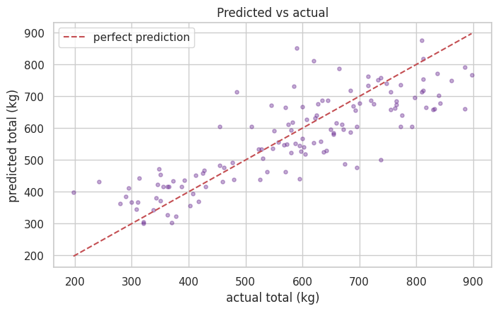

```python
plt.scatter(y_test, pred_rf, alpha=0.4, s=14, color="#6a2c91")
lims = [y_test.min(), y_test.max()]
plt.plot(lims, lims, "r--", label="perfect prediction")
plt.xlabel("actual total (kg)"); plt.ylabel("predicted total (kg)")
plt.title("Predicted vs actual"); plt.legend(); plt.show()
```

### Feature importance

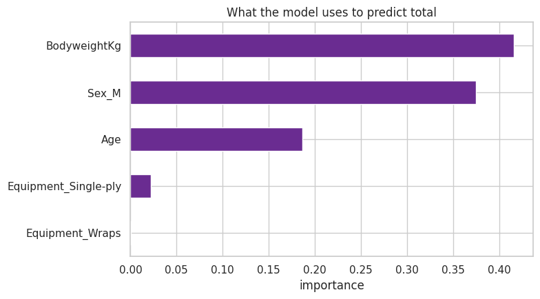

```
BodyweightKg            0.416033
Sex_M                   0.374527
Age                     0.186795
Equipment_Single-ply    0.022188
Equipment_Wraps         0.000457
dtype: float64
```

```python
importances = pd.Series(rf.feature_importances_, index=X.columns).sort_values()
importances.plot(kind="barh", color="#6a2c91")
plt.title("What the model uses to predict total"); plt.xlabel("importance")
plt.tight_layout(); plt.show()
print(importances.sort_values(ascending=False))
```

**Bodyweight** and **sex** dominate the prediction, with equipment and age contributing less. This matches domain knowledge: how much a competitor totals is driven mostly by their size and sex.

## Summary

The project ran a complete pipeline on real competition data: loading and inspection; cleaning across dirty categories, impossible outliers, and missing values; exploratory analysis; feature engineering; modeling with two algorithms under a proper train/test split; and evaluation with MAE, R², and feature importance. The models predicted a lifter's total to within roughly **70 kg** on unseen data and explained about **70% of the variance**, with the simple linear model matching the random forest and bodyweight and sex the dominant drivers.

Data: real IPF competition results from OpenPowerlifting (public domain), via the TidyTuesday project. This notebook uses a representative sample; the full IPF subset holds 41,152 records.